# Logistic regression with R

Binary responses, probabilities and classification

O Rodriguez de Rivera Ortega, PhD

University of Exeter

# 1 Session overview

## 1.1 Learning outcomes

By the end of this section, students should be able to:

- fit a logistic regression using `glm(..., family = binomial)`;
- explain the difference between probabilities, odds and log-odds;
- convert predicted probabilities into classifications using a threshold;
- evaluate a simple classifier using a confusion matrix;
- explain why threshold choice depends on the scientific or decision context.

## 1.2 Setup

```r
library(tidyverse)
library(palmerpenguins)

theme_set(theme_minimal(base_size = 12))
```

# 2 Binary response data

## 2.1 Example: penguin sex from body measurements

We will model whether a penguin is male using body measurements and species.

This is a convenient teaching example because the response is binary and the predictors are familiar, but the same framework applies to ecological questions such as:

- species present or absent;
- nest successful or unsuccessful;
- disease detected or not detected;
- habitat suitable or unsuitable.

```r
penguins_bin <- penguins %>%
  drop_na(species, sex, body_mass_g, bill_depth_mm, flipper_length_mm) %>%
  mutate(
    male = if_else(sex == "male", 1L, 0L),
    sex = fct_drop(sex)
  )

count(penguins_bin, species, sex)
```

| species | sex | n |
| --- | --- | --- |
| Adelie | female | 73 |
| Adelie | male | 73 |
| Chinstrap | female | 34 |
| Chinstrap | male | 34 |
| Gentoo | female | 58 |
| Gentoo | male | 61 |

## 2.2 Explore the data

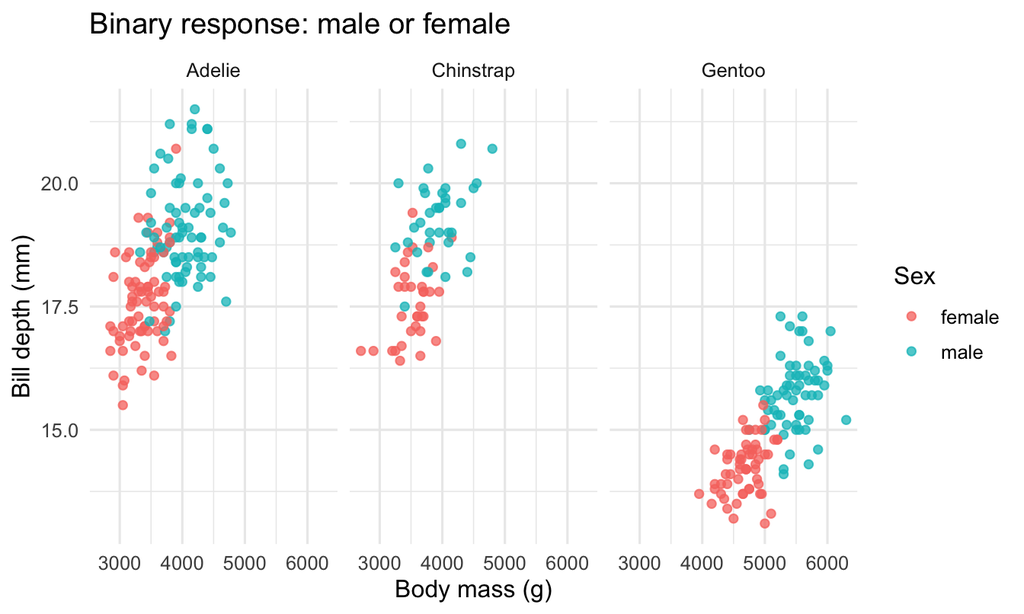

```r
ggplot(penguins_bin,
       aes(x = body_mass_g, y = bill_depth_mm, colour = sex)) +
  geom_point(alpha = 0.75) +
  facet_wrap(~ species) +
  labs(
    title = "Binary response: male or female",
    x = "Body mass (g)",
    y = "Bill depth (mm)",
    colour = "Sex"
  )
```

# 3 The logistic model

## 3.1 Why not use a linear model?

A linear model for a binary response can produce fitted values below 0 or above 1.

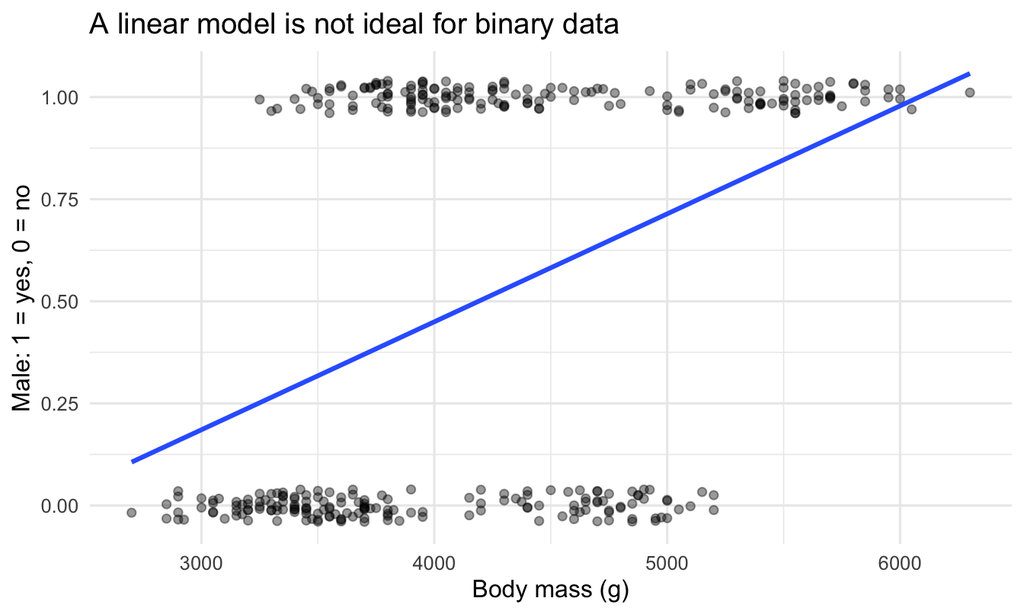

```r
ggplot(penguins_bin, aes(x = body_mass_g, y = male)) +
  geom_jitter(height = 0.04, width = 0, alpha = 0.4) +
  geom_smooth(method = "lm", se = FALSE) +
  labs(
    title = "A linear model is not ideal for binary data",
    x = "Body mass (g)",
    y = "Male: 1 = yes, 0 = no"
  )
```

## 3.2 Logistic regression

For a binary response:

$$Y_i \sim
\mathrm{Bernoulli}(p_i).$$

The logistic regression model uses the logit link:

$$\log\left(\frac{p_i}{1-p_i}\right) =
\eta_i = \beta_0 + \beta_1 x_{1i} + \cdots + \beta_p
x_{pi}.$$

The inverse-logit maps any real number back to a probability between 0 and 1:

$$p_i = \frac{\exp(\eta_i)}{1 +
\exp(\eta_i)}.$$

In R, we use:

```r
glm(y ~ x1 + x2, family = binomial(link = "logit"), data = my_data)
```

## 3.3 Fit a first model

```r
sex_glm <- glm(
  male ~ body_mass_g + bill_depth_mm + species,
  family = binomial(link = "logit"),
  data = penguins_bin
)

summary(sex_glm)
```

```
##
## Call:
## glm(formula = male ~ body_mass_g + bill_depth_mm + species, family = binomial(link = "logit"),
##     data = penguins_bin)
##
## Coefficients:
##                    Estimate Std. Error z value Pr(>|z|)
## (Intercept)      -5.435e+01  6.559e+00  -8.286  < 2e-16 ***
## body_mass_g       6.320e-03  9.209e-04   6.863 6.74e-12 ***
## bill_depth_mm     1.694e+00  2.926e-01   5.789 7.07e-09 ***
## speciesChinstrap -2.708e-01  5.058e-01  -0.535   0.5924
## speciesGentoo    -2.895e+00  1.640e+00  -1.765   0.0776 .
## ---
## Signif. codes:  0 '***' 0.001 '**' 0.01 '*' 0.05 '.' 0.1 ' ' 1
##
## (Dispersion parameter for binomial family taken to be 1)
##
##     Null deviance: 461.61  on 332  degrees of freedom
## Residual deviance: 161.02  on 328  degrees of freedom
## AIC: 171.02
##
## Number of Fisher Scoring iterations: 7
```

## 3.4 Coefficients and odds ratios

The coefficients are on the log-odds scale. Exponentiating them gives odds ratios.

```r
tibble(
  term = names(coef(sex_glm)),
  estimate_log_odds = coef(sex_glm),
  odds_ratio = exp(coef(sex_glm))
)
```

| term | estimate_log_odds | odds_ratio |
| --- | --- | --- |
| (Intercept) | -54.34963272 | 2.490316e-24 |
| body_mass_g | 0.00632037 | 1.006340e+00 |
| bill_depth_mm | 1.69384243 | 5.440345e+00 |
| speciesChinstrap | -0.27076820 | 7.627933e-01 |
| speciesGentoo | -2.89504527 | 5.529652e-02 |

Interpretation example:

- `body_mass_g` is continuous, so `exp(coef)` gives the multiplicative change in odds for a 1 g increase.
- A 1 g change is very small, so it is often clearer to rescale body mass.

## 3.5 Rescale predictors for interpretation

```r
penguins_bin <- penguins_bin %>%
  mutate(body_mass_100g = body_mass_g / 100)

sex_glm_100g <- glm(
  male ~ body_mass_100g + bill_depth_mm + species,
  family = binomial,
  data = penguins_bin
)

exp(coef(sex_glm_100g))
```

```
##      (Intercept)   body_mass_100g    bill_depth_mm speciesChinstrap
##     2.490316e-24     1.881439e+00     5.440345e+00     7.627933e-01
##    speciesGentoo
##     5.529652e-02
```

Now the odds ratio for body mass refers to a 100 g increase.

# 4 Predicted probabilities

## 4.1 Prediction on the response scale

```r
head(predict(sex_glm_100g, type = "link"))      # log-odds
```

```
##          1          2          3          4          5          6
##  1.0266071 -0.8593696 -3.3192675  0.1468016  3.6128707 -1.2878973
```

```r
head(predict(sex_glm_100g, type = "response"))  # probabilities
```

```
##          1          2          3          4          5          6
## 0.73625758 0.29747107 0.03491608 0.53663464 0.97373420 0.21620893
```

Use `type = "response"` when you want predicted probabilities.

## 4.2 Plot predicted probabilities

```r
new_penguins <- expand_grid(
  body_mass_100g = seq(min(penguins_bin$body_mass_100g),
                       max(penguins_bin$body_mass_100g),
                       length.out = 100),
  bill_depth_mm = mean(penguins_bin$bill_depth_mm),
  species = factor(levels(penguins_bin$species),
                   levels = levels(penguins_bin$species))
)

pred_link <- predict(sex_glm_100g,
                     newdata = new_penguins,
                     type = "link",
                     se.fit = TRUE)

new_penguins <- new_penguins %>%
  mutate(
    prob_male = plogis(pred_link$fit),
    lower = plogis(pred_link$fit - 1.96 * pred_link$se.fit),
    upper = plogis(pred_link$fit + 1.96 * pred_link$se.fit),
    body_mass_g = body_mass_100g * 100
  )
```

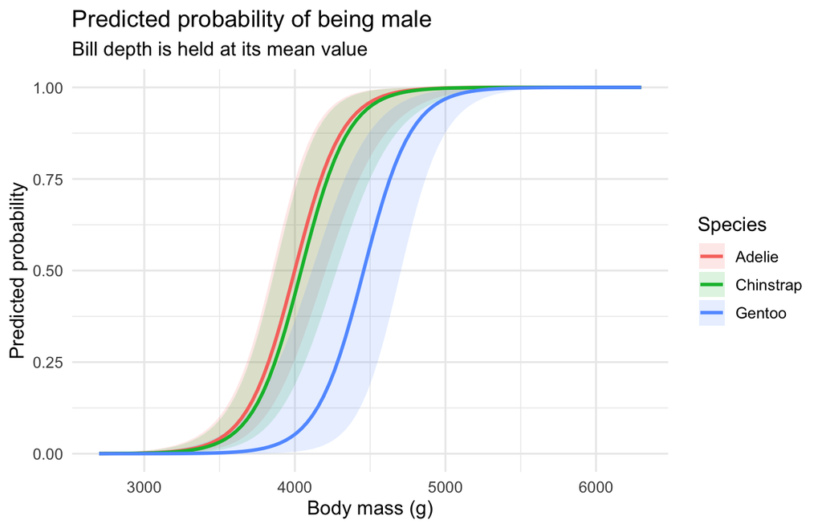

```r
ggplot(new_penguins,
       aes(x = body_mass_g, y = prob_male, colour = species, fill = species)) +
  geom_ribbon(aes(ymin = lower, ymax = upper), alpha = 0.15, colour = NA) +
  geom_line(linewidth = 1) +
  labs(
    title = "Predicted probability of being male",
    subtitle = "Bill depth is held at its mean value",
    x = "Body mass (g)",
    y = "Predicted probability",
    colour = "Species",
    fill = "Species"
  )
```

# 5 Classification

## 5.1 From probability to class

Predicted values from logistic regression are probabilities, not classes.

To classify observations, we choose a threshold. A common starting point is 0.5:

```r
penguins_bin <- penguins_bin %>%
  mutate(
    prob_male = predict(sex_glm_100g, type = "response"),
    predicted_male = if_else(prob_male > 0.5, 1L, 0L)
  )

penguins_bin %>%
  select(species, sex, male, prob_male, predicted_male) %>%
  slice(1:8)
```

| species | sex | male | prob_male | predicted_male |
| --- | --- | --- | --- | --- |
| Adelie | male | 1 | 0.73625758 | 1 |
| Adelie | female | 0 | 0.29747107 | 0 |
| Adelie | female | 0 | 0.03491608 | 0 |
| Adelie | female | 0 | 0.53663464 | 1 |
| Adelie | male | 1 | 0.97373420 | 1 |
| Adelie | female | 0 | 0.21620893 | 0 |
| Adelie | male | 1 | 0.99977460 | 1 |
| Adelie | female | 0 | 0.01321861 | 0 |

## 5.2 Confusion matrix

```r
confusion <- table(
  predicted = factor(penguins_bin$predicted_male, levels = c(0, 1)),
  observed = factor(penguins_bin$male, levels = c(0, 1))
)

confusion
```

```
##          observed
## predicted   0   1
##         0 147  15
##         1  18 153
```

Rows are predicted classes; columns are observed classes.

## 5.3 Accuracy, sensitivity and specificity

```r
accuracy <- sum(diag(confusion)) / sum(confusion)
sensitivity <- confusion["1", "1"] / sum(confusion[, "1"])
specificity <- confusion["0", "0"] / sum(confusion[, "0"])

tibble(
  metric = c("accuracy", "sensitivity", "specificity"),
  value = c(accuracy, sensitivity, specificity)
)
```

| metric | value |
| --- | --- |
| accuracy | 0.9009009 |
| sensitivity | 0.9107143 |
| specificity | 0.8909091 |

Definitions:

- **Accuracy:** proportion of all observations classified correctly.
- **Sensitivity:** proportion of true males classified as male.
- **Specificity:** proportion of true females classified as female.

## 5.4 Thresholds are decisions

A threshold of 0.5 is not always best.

Use a lower threshold when false negatives are costly, for example disease detection or invasive species surveillance.

Use a higher threshold when false positives are costly, for example expensive follow-up sampling.

```r
threshold_metrics <- function(threshold) {
  pred <- if_else(penguins_bin$prob_male > threshold, 1L, 0L)
  tab <- table(
    predicted = factor(pred, levels = c(0, 1)),
    observed = factor(penguins_bin$male, levels = c(0, 1))
  )
  tibble(
    threshold = threshold,
    accuracy = sum(diag(tab)) / sum(tab),
    sensitivity = tab["1", "1"] / sum(tab[, "1"]),
    specificity = tab["0", "0"] / sum(tab[, "0"])
  )
}

map_dfr(seq(0.2, 0.8, by = 0.1), threshold_metrics)
```

| threshold | accuracy | sensitivity | specificity |
| --- | --- | --- | --- |
| 0.2 | 0.8648649 | 0.9642857 | 0.7636364 |
| 0.3 | 0.8918919 | 0.9523810 | 0.8303030 |
| 0.4 | 0.9129129 | 0.9404762 | 0.8848485 |
| 0.5 | 0.9009009 | 0.9107143 | 0.8909091 |
| 0.6 | 0.8828829 | 0.8511905 | 0.9151515 |
| 0.7 | 0.8918919 | 0.8214286 | 0.9636364 |
| 0.8 | 0.8738739 | 0.7797619 | 0.9696970 |

## 5.5 Optional: ROC curve

The ROC curve summarises sensitivity and specificity across all possible thresholds.

```r
library(pROC)
roc_obj <- roc(penguins_bin$male, penguins_bin$prob_male)
plot(roc_obj, print.auc = TRUE)
```

[output not shown]

# 6 Model comparison

## 6.1 Add an interaction?

The effect of body mass may differ by species.

```r
sex_glm_interaction <- glm(
  male ~ body_mass_100g * species + bill_depth_mm,
  family = binomial,
  data = penguins_bin
)

AIC(sex_glm_100g, sex_glm_interaction)
```

|  | df | AIC |
| --- | --- | --- |
| sex_glm_100g | 5 | 171.0241 |
| sex_glm_interaction | 7 | 166.9824 |

Lower AIC indicates better expected out-of-sample predictive performance, but the difference should be interpreted with the scientific question in mind.

## 6.2 Likelihood-ratio test for nested models

```r
anova(sex_glm_100g, sex_glm_interaction, test = "Chisq")
```

|  | Resid. Df | Resid. Dev | Df | Deviance | Pr(>Chi) |
| --- | --- | --- | --- | --- | --- |
| 1 | 328 | 161.0241 | NA | NA | NA |
| 2 | 326 | 152.9824 | 2 | 8.041669 | 0.01793799 |

This test is appropriate because the first model is nested within the interaction model.

# 7 Practical exercise

## 7.1 Exercise: build your own logistic model

Use the penguin data to answer the following questions.

1. Fit a logistic regression for male using: # flipper_length_mm + body_mass_100g + species
2. Compare it with sex_glm_100g using AIC().
3. Plot predicted probabilities across flipper length.
4. Change the classification threshold from 0.5 to 0.4.

What happens to sensitivity and specificity?

## 7.2 Take-home messages

- Logistic regression models a probability.
- Coefficients are on the log-odds scale.
- `exp(coef(model))` gives odds ratios.
- `predict(model, type = "response")` gives probabilities.
- Classification requires a threshold, and threshold choice is a decision, not a default truth.